# Part I - Exploration of data on fordgobike trips in San francisco for the month of febraury in the year 2019

## by Afariogun John Tolulope

## Introduction

> This data set includes information about individual rides made in a bike-sharing system covering the greater San Francisco Bay area for the month of february

# ASSESSING THE DATA

```
(183412, 16)
```

```
<class 'pandas.core.frame.DataFrame'>
RangeIndex: 183412 entries, 0 to 183411
Data columns (total 16 columns):
duration_sec               183412 non-null int64
start_time                 183412 non-null object
end_time                   183412 non-null object
start_station_id           183215 non-null float64
start_station_name         183215 non-null object
start_station_latitude     183412 non-null float64
start_station_longitude    183412 non-null float64
end_station_id             183215 non-null float64
end_station_name           183215 non-null object
end_station_latitude       183412 non-null float64
end_station_longitude      183412 non-null float64
bike_id                    183412 non-null int64
user_type                  183412 non-null object
member_birth_year          175147 non-null float64
member_gender              175147 non-null object
bike_share_for_all_trip    183412 non-null object
dtypes: float64(7), int64(2), object(7)
memory usage: 22.4+ MB
```

|  | duration_sec | start_time | end_time | start_station_id | start_station_name | start_station_latitude | start_station_longitude | end_station_id | end_station_name | end_station_latitude | end_station_longitude | bike_id | user_type | member_birth_year | member_gender | bike_share_for_all_trip |
| --- | --- | --- | --- | --- | --- | --- | --- | --- | --- | --- | --- | --- | --- | --- | --- | --- |
| 0 | 52185 | 2019-02-28 17:32:10.1450 | 2019-03-01 08:01:55.9750 | 21.0 | Montgomery St BART Station (Market St at 2nd St) | 37.789625 | -122.400811 | 13.0 | Commercial St at Montgomery St | 37.794231 | -122.402923 | 4902 | Customer | 1984.0 | Male | No |
| 1 | 42521 | 2019-02-28 18:53:21.7890 | 2019-03-01 06:42:03.0560 | 23.0 | The Embarcadero at Steuart St | 37.791464 | -122.391034 | 81.0 | Berry St at 4th St | 37.775880 | -122.393170 | 2535 | Customer | NaN | NaN | No |
| 2 | 61854 | 2019-02-28 12:13:13.2180 | 2019-03-01 05:24:08.1460 | 86.0 | Market St at Dolores St | 37.769305 | -122.426826 | 3.0 | Powell St BART Station (Market St at 4th St) | 37.786375 | -122.404904 | 5905 | Customer | 1972.0 | Male | No |
| 3 | 36490 | 2019-02-28 17:54:26.0100 | 2019-03-01 04:02:36.8420 | 375.0 | Grove St at Masonic Ave | 37.774836 | -122.446546 | 70.0 | Central Ave at Fell St | 37.773311 | -122.444293 | 6638 | Subscriber | 1989.0 | Other | No |
| 4 | 1585 | 2019-02-28 23:54:18.5490 | 2019-03-01 00:20:44.0740 | 7.0 | Frank H Ogawa Plaza | 37.804562 | -122.271738 | 222.0 | 10th Ave at E 15th St | 37.792714 | -122.248780 | 4898 | Subscriber | 1974.0 | Male | Yes |

### The structure of the dataset?

> There are 183412 records of trip in the dataset. Most variables are numeric in nature, but the variables user_type,station names are cateogrical in nature The dataset is noted to contain 183,412 unique entries(rows) and this are all grouped under 16 variables (columns)
- duration_sec - total time of the trip in seconds
- start_time - the starting time for the trip
- end_time - the time when the trip came to an end
- start_station_id - a unique id given to the specific station where the trip was noted to start
- start_station_name - the name of the station where the trip started
- start_station_latitude - the latitude co-ordinate of the station where the trip started
- start_station_longitude - the longitude co-ordinate of the station where the trip started
- end_station_id - a unique id given to the specific station where the trip was noted to end
- end_station_name - the name of the station where the trip ended
- end_station_latitude - the latitude co-ordinate of the station where trip ended
- end_station_longitude - the longitude co-ordinate of the station where trip ended
- bike_id - a unique id for the bikes
- user_type - the type ascribed to the user if it is a subscriber or just a random cutomer, other
- member_birth_year - the birth year of the user
- member_gender - what gender the user belongs to, if male, female or other
- bike_share_for_all_trip - if the user shared the bike at all for the trip

### What is/are the main feature(s) of interest in your dataset?

- What variables influence trip duration

### What features in the dataset do you think will help support your investigation into your feature(s) of interest?

- Trip Duration
- User Type
- Member gender
- Member age

## Preliminary Wrangling

#### Creating a copy of the original data to carry out any data wrangling operations:

- Converting columns **start_time** and **end_time** to DateTime format
- Extracting the starting hour of the trip from the **start_time** into a **start_hour** column
- Extracting the starting day of the trip from the **start_time** into a **day** column
- Extracting the age of the user bu substracting the **member_birth_year** from year of the trips into a **age** column, but first converting the **member_birth_year** to a *float* datattype
- Calculating the distance of the trip in kilometer using python GeoPy package and collating them in a **distance_(km)** column.
- Filling all categorical variable's missing value with unknown and numerical with 0, so as to try to maintain the integrity of the dataset

## Taking a look at our dataframe after wrangling our data set we have

```
<class 'pandas.core.frame.DataFrame'>
RangeIndex: 183412 entries, 0 to 183411
Data columns (total 20 columns):
duration_sec               183412 non-null int64
start_time                 183412 non-null datetime64[ns]
end_time                   183412 non-null datetime64[ns]
start_station_id           183412 non-null category
start_station_name         183412 non-null category
start_station_latitude     183412 non-null float64
start_station_longitude    183412 non-null float64
end_station_id             183412 non-null category
end_station_name           183412 non-null category
end_station_latitude       183412 non-null float64
end_station_longitude      183412 non-null float64
bike_id                    183412 non-null category
user_type                  183412 non-null category
member_birth_year          183412 non-null float64
member_gender              183412 non-null category
bike_share_for_all_trip    183412 non-null object
start_hour                 183412 non-null category
day                        183412 non-null object
age                        183412 non-null float64
distance_(km)              183412 non-null float64
dtypes: category(8), datetime64[ns](2), float64(7), int64(1), object(2)
memory usage: 19.3+ MB
```

|  | duration_sec | start_time | end_time | start_station_id | start_station_name | start_station_latitude | start_station_longitude | end_station_id | end_station_name | end_station_latitude | end_station_longitude | bike_id | user_type | member_birth_year | member_gender | bike_share_for_all_trip | start_hour | day | age | distance_(km) |
| --- | --- | --- | --- | --- | --- | --- | --- | --- | --- | --- | --- | --- | --- | --- | --- | --- | --- | --- | --- | --- |
| 0 | 52185 | 2019-02-28 17:32:10.145 | 2019-03-01 08:01:55.975 | 21 | Montgomery St BART Station (Market St at 2nd St) | 37.789625 | -122.400811 | 13 | Commercial St at Montgomery St | 37.794231 | -122.402923 | 4902 | Customer | 1984.0 | Male | No | 17 | Thursday | 35.0 | 0.543983 |
| 1 | 42521 | 2019-02-28 18:53:21.789 | 2019-03-01 06:42:03.056 | 23 | The Embarcadero at Steuart St | 37.791464 | -122.391034 | 81 | Berry St at 4th St | 37.775880 | -122.393170 | 2535 | Customer | 0.0 | Unknown | No | 18 | Thursday | 0.0 | 1.739909 |
| 2 | 61854 | 2019-02-28 12:13:13.218 | 2019-03-01 05:24:08.146 | 86 | Market St at Dolores St | 37.769305 | -122.426826 | 3 | Powell St BART Station (Market St at 4th St) | 37.786375 | -122.404904 | 5905 | Customer | 1972.0 | Male | No | 12 | Thursday | 47.0 | 2.705390 |
| 3 | 36490 | 2019-02-28 17:54:26.010 | 2019-03-01 04:02:36.842 | 375 | Grove St at Masonic Ave | 37.774836 | -122.446546 | 70 | Central Ave at Fell St | 37.773311 | -122.444293 | 6638 | Subscriber | 1989.0 | Other | No | 17 | Thursday | 30.0 | 0.260896 |
| 4 | 1585 | 2019-02-28 23:54:18.549 | 2019-03-01 00:20:44.074 | 7 | Frank H Ogawa Plaza | 37.804562 | -122.271738 | 222 | 10th Ave at E 15th St | 37.792714 | -122.248780 | 4898 | Subscriber | 1974.0 | Male | Yes | 23 | Thursday | 45.0 | 2.412017 |

# EXPLORATORY DATA ANALYSIS

## Univariate Exploration

## Creating a new dataframe whivh contains all of the columns that are to be used in this analysis, which are the:

```
<class 'pandas.core.frame.DataFrame'>
RangeIndex: 183412 entries, 0 to 183411
Data columns (total 13 columns):
duration_sec               183412 non-null int64
start_hour                 183412 non-null category
start_time                 183412 non-null datetime64[ns]
end_time                   183412 non-null datetime64[ns]
day                        183412 non-null object
start_station_name         183412 non-null category
end_station_name           183412 non-null category
bike_id                    183412 non-null category
user_type                  183412 non-null category
age                        183412 non-null float64
bike_share_for_all_trip    183412 non-null object
member_gender              183412 non-null category
distance_(km)              183412 non-null float64
dtypes: category(6), datetime64[ns](2), float64(2), int64(1), object(2)
memory usage: 11.6+ MB
```

Taking a look at the Distributions

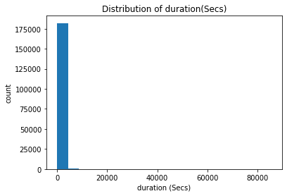

When assessing the data earlier there were some values which were greater than 20,000 secs in the dataset and the prescence of higher values in this plot lends credence to that fact. So redoing the plot but this time with some xlims to properly see the distribution

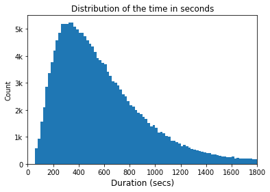

We can see from the plot that it is right skewed and unimodal, with a peak between 200 and 400 secs, maybe 300 seconds.

Displaying the distribution again but this time with the time in minutes for better visuals

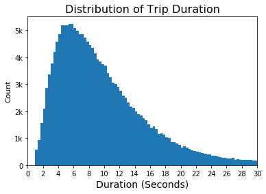

Taking a look at this visualization again, but with the tick marks in mins for better visualization. This shows us that the trips peaked at 5mins which is at 300 seconds, which is the duration most trips took

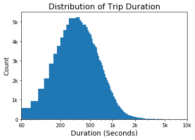

After applying log transfrom to the data we can see that it is still unimodal, but looks somewhat symmetric, still right-skewed though.

Examining the distance distribution

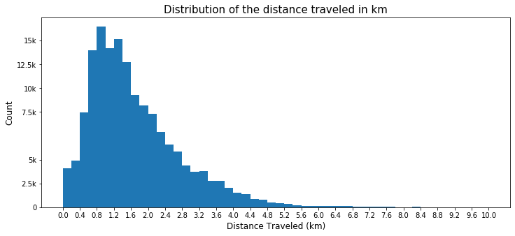

Taking a look at the distances traveled, we can see that the bikes were generally used for trips within the range of 2km with the most trips being between the distances 0.8 and 1.2 km, our data is right skewed and bimodal

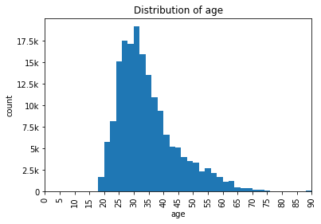

From the this plot, the the most trips where by people within the age range of age 25 and 40, which we can assume to be the working class or more of the youth of the population.

Going deeper into the age distribution to see the users 25 most frequent ages

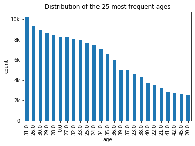

Further analysis shows that the age with the most trips is at age 31, followed by 26 and so on. Further supporting the theory that fordgobike users are workers

Taking a glance at the distribution of the user type

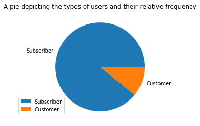

As seen the amount of subscribers which use fordgobikes dwarf those who are just casual or one off users

Using a barplot to actaully see an approxiamte count of each user type

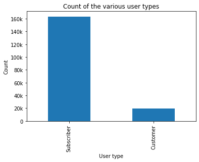

Taking a closer look, as above we see that while subscribers took just north of 160000 trips, customers took barely 20,000 trips

Examining with a bar chart

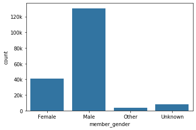

Males make up most of fordgobike's users more than 120,000 trips were made by males. Though is this because of bikes require more strenous work to use. This will be further investigated during the Bivariate exploration. The female gender are the next most users of firdgibikes around 40,000 trips. While those who identify as Other gender use forgobikes barely and those whose gender are not registered come up as the third most populous user of fordgobikes

Here we can see clearly how the gender distribution is in the dataset

Going more into other categorical data like the **bike_share_for_all_trip**

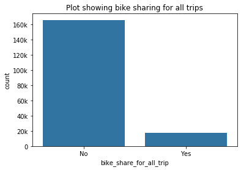

From this we can say that most people didn't share their bikes for the duration of their trips

Taking a look at the distribution of trips over the week

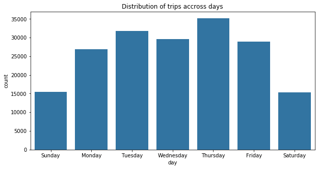

Most trips were taken during weekdays, which might be during work hour while the least were taken during the weekend

Taking a look at the distribution of trips over the month of february

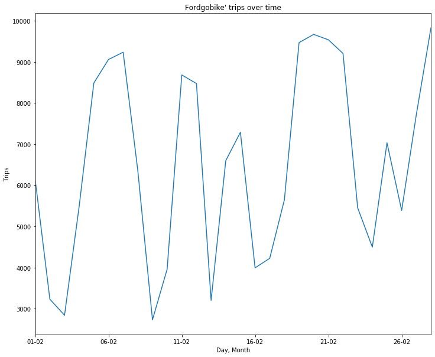

Taking a look at the progression of number of trips over the month of febraury we can see that there is a gradual increase trend in the number of trips which also suggests an increase in the number of users

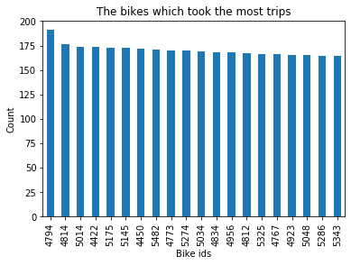

This shows the distribution of the top 20 most used bikes

## Bivariate Exploration

### Taking a look at the influence of member_gender and user_type on the number of trips

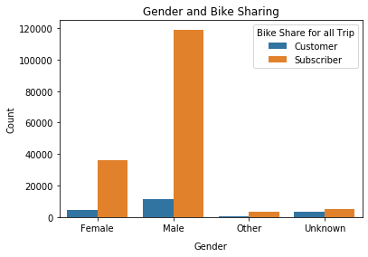

Male subscribers have the greatest concentration which brings in a bias in our dataset and distorts whatever theory that can be made on bike sharing

### Taking a glance at the influence of age on the other variables

First looking at how long was the trip for users at different ages

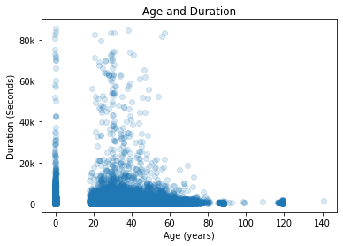

First we might notice that there are multiple outliers in the plot. first is the the 0 age which was given to those whose age is unknown it detracts from the plot, also we have multiple outliers starting at 100 years, as people above or even close to that age shouldn't be able to ride bikes, we will remove that from the visualization

Applying a limit of 15 and 95 years to the plot

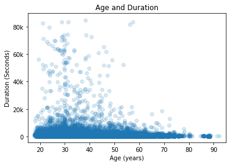

Now taking a look at this plot, we can see that the longest trips were taken by those below 60 years of age and there is high density of users at ages until 50 years, were it begins to taper out and we have the least duration at age 80, excluding additional outliers

Taking a look at the relationshiip between age and member gender

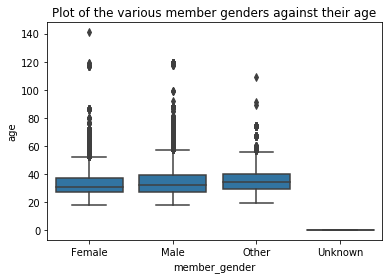

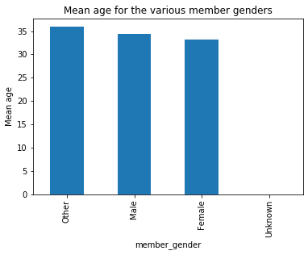

Users who identify as Other are on a average the older of the different genders.

Checking to see the ages of those who take trips at various hours of the day

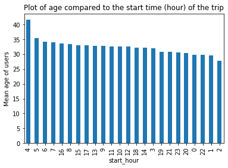

The mean age of those who took trips starting at hour 4:00am are the most.

Trying to find if there is a direct relationship between how old the users were and the distance they took a trip for

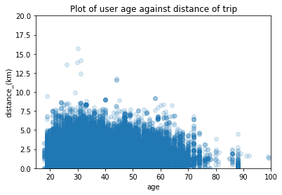

A greater concentration of users who take trips of longer distances are within the age range 20 and 50. Corellating with the earlier assumption during the univariate analysis

Applying a log transfrom to the y-axis as the values were too large to give a concrete result

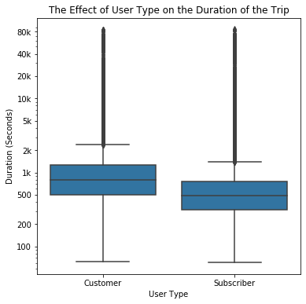

After the application of the log transform we can clearly see that Subscribers generally spend lesser time on trips as opposed to just customers. This might be due to special priviledges given to subscribers, but it might also be due to other factors we will investigate this further in our analysis

Taking a look at influence of member_gender on duration of trip, simply reusing the same code as before for the log transform but this time with *member_gender* instead of *user_type*

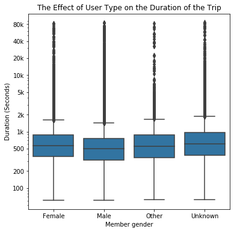

Taking a look at the duration with resspect to gender, we find that males generally spend lesser time on trips.

Does bike sharing have any influence on the trip duration

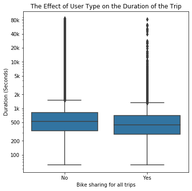

The visualization shows that users who do not share bikes generally spend more time on trips

Applying a log transformthe duration data and plotting it against the distance of trip

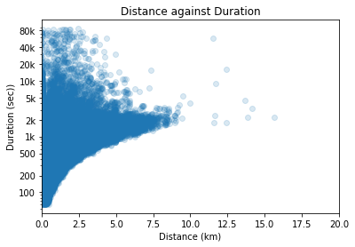

As seen there is a generally direct correllation between Distance of trip and the trip duration

## Multivariate Plots

Making some multivariate plots to confirm the relationships between:

- distance of the trip
- user type
- duration of trip
- bike_share_for_all_trip
- member gender
- age

Introducing **bike_share_for_all_trip** as a third variable in the distance vs duration plot to see its influence

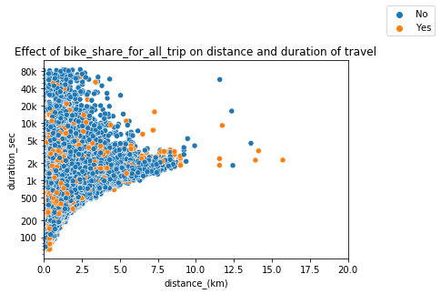

From this plot we can see that most of the trips in which bikes were shared were mostly at a small distance and did not last for a long time. This actually confirms for us our earlier analysis that those who share bikes have a shorter trip period than those who didn't

Introducing **user_type** as a third variable in the distance vs duration plot to see its influence

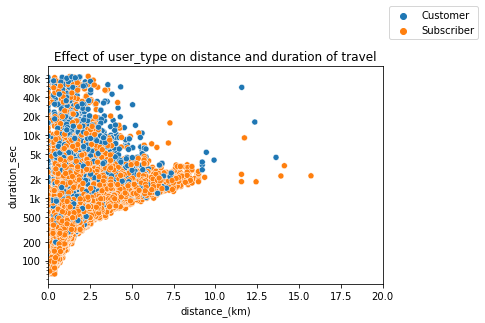

This plot shows that most subscribers spend lesser time on their trips and also go on short trips as opposed to regular customers

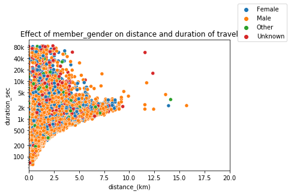

There is a far greater distribution of men who go on further trips but also spend lesser times on their trips, though considering that the data contains more of males than female this may be a bias

Comparing the effect of user_type and member_gender on distance vs duration plot

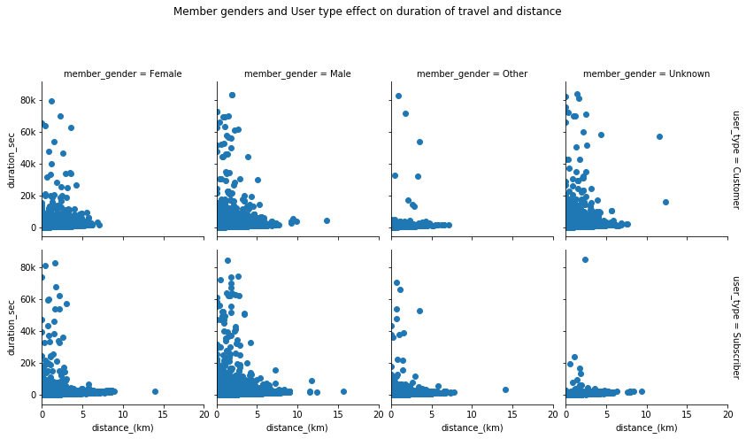

Creating a visual of user_type over various distances

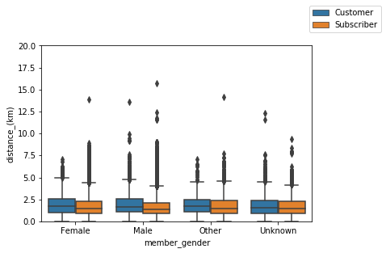

From this visualization a large amount of customers go on longer trips, with the **Other** gender being the most frequent, this is the same for subscribers. Though there are more outliers of male Subscribers going on longer trips. Those who didn't ascribe a gender to themselves though also follow the trends of the **Other** gender closely

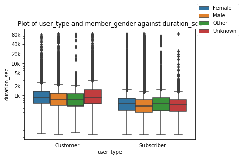

From the analysis Males travels are faster and take lesser time compared to the rest of the genders

# Conclusion